# PySpark material

[figure not shown]

**Pre-Requisites**: Exposure to Python Programming

**Brief Description**: Spark is a Distributed Computing Framework used for processing, querying and analysing Big Data. It is open source and it can run tasks faster than traditional software. It is written in the programming language Scala, but it also has support for other widely used programming languages; Java, Python, R and SQL. In this course, we learn Spark using Python (pySpark).

Instructions are given on setting up pyspark on databricks https://databricks.com/ including how to register, login and start a Cluster and a Notebook on. Before starting this course you should have already done all these.

**Aims, Objectives and Intended Learning Outcomes**:

By the end of this course, you should be able to:

- Understand what Big Data is and its characteristics
- Create clusters on a Distributed Computing Framework (DCF)
- Understand what Spark is and how it is used on a DCF
- Use pySpark in a DCF to process and analyse Big Data

**Datasets: department_budget.csv, Travel_to_Work_Areas.csv, Travel_to_Work_Small_Areas.csv, Item_Price_Data.csv, Item_Defect_Dataset.csv, Item_Defect_Dataset_Modified.csv**

# 1 Introduction to Spark

## 1.1 Big Data

The term Big Data refers to data sets that are too large and complex for traditional data processing methods struggle to handle. Nowadays, such datasets are everywhere and contain information that we want to reveal. The “4 Vs” are key characteristics of big data:

- Volume : Massive amounts of data generated
- Velocity : High speed of data creation and processing
- Variety : Diverse types and sources of data
- Veracity : Ensuring data quality and reliability

These characteristics present challenges and opportunities in data analysis, storage and utilisation across different domains.

## 1.2 Distributed Computing Framework (DCF)

Distributed Computing is a system where multiple machines are working and communicating simultaneously with each other. It is used when there is a need for fast processing of a huge amount of data. The data is split into discrete, non-overlapping sections, with each machine running operations on one section of data. The cluster as a whole then reports up to the driver any results from the operations.

**Famous Example of how DCF works:**

I am in a library and I want to count the exact number of books in an hour. To achieve that, I call as many people as possible and divide the areas among them in a non-overlapping system. I ask them to be back right before the hour. Once they are back, I simply add the numbers to calculate the exact number of books in the library.

Apache Hadoop and Apache Spark are designed to do exactly that. They are designed to make resource allocation and result collecting a straightforward process.

## 1.3 What is Spark?

Spark is a relatively new DCF used for processing, querying and analysing Big Data. It is open source and it can run tasks faster than previous DCFs by using in-memory computation. It is written in the programming language Scala, but it also has support for other widely used programming languages; Java, Python, R and SQL, and is used as an interface to control entire clusters of computers.

[figure not shown]

## 1.4 Why use Spark?

### 1.4.1 Over traditional software

Spark is inherently scalable, and can handle vast amounts of data beyond the reach of traditional software and data analysis methods. For datasets too large to be held in normal computer memory, operations can be run over the entire data at once.

### 1.4.2 Over other DCFs

Spark’s key advantage is the ability to perform in memory computation. The entire data set can be held across the distributed cluster, operations and transformations can be applied, without having to write to a hard drive. Previous DCFs such as Hadoop had to read and write to the file system with each transformation, adding a huge time overhead (especially when the data is very large.)

Spark also has Lazy Evaluation - it will only evaluate commands when it is needed, and will identify the optimal, most efficient, way to perform a series of commands. For example, spark can be tasked to perform many transformations to manipulate the data, but until a command requiring a direct response - such as a count of the data - is issued, the manipulations will be queued up and optimised.

### 1.4.3 Advantages, Disadvantages, Limitations of using Spark

**Advantages:**

1. Fast processing of Big Data compared with other DCFs
2. Capable of handling large data sets where traditional software fails
3. Supports multiple languages (Scala, Java, R, Python)
4. Lazy Evaluation: data is evaluated only when an action is called for computation.

**Disadvantages and Limitations:**

1. It does not have its own file management system (relying on Hadoop or other platforms). When it is used with Hadoop, it supports a limited number of large files, thus ending up with a lot of small files.
2. Some failures are so vague that it is not easy to understand what they mean and where they are coming from.
3. There are not as many ready-made algorithms as using traditional languages (e.g. Python).
4. Python and R users are always a step behind in updates compared to Scala and Java users - features can be slow to be implemented.

## 1.5 Who uses Spark?

Data engineers, data scientists, application developers.

Companies such as TripAdvisor, Yahoo!, eBay, MyFitnessPal, and the ONS.

## 1.6 How does Spark run on a Cluster

A Cluster is the group of computers (nodes) which are all connected and coordinated together to perform tasks. Your own laptop could be part of this group of computers, or the one controlling them.

The Driver Process runs the main program, and queues tasks for the cluster to complete. Any results get collected and brought back to the driver.

Spark uses a Cluster Manager to coordinate the work across such a cluster for you, it directs the workers of the cluster as to which of the tasks set by the Driver they should be doing, .

The Executors, or workers, do the assigned tasks (executing code) and report back to the Driver.

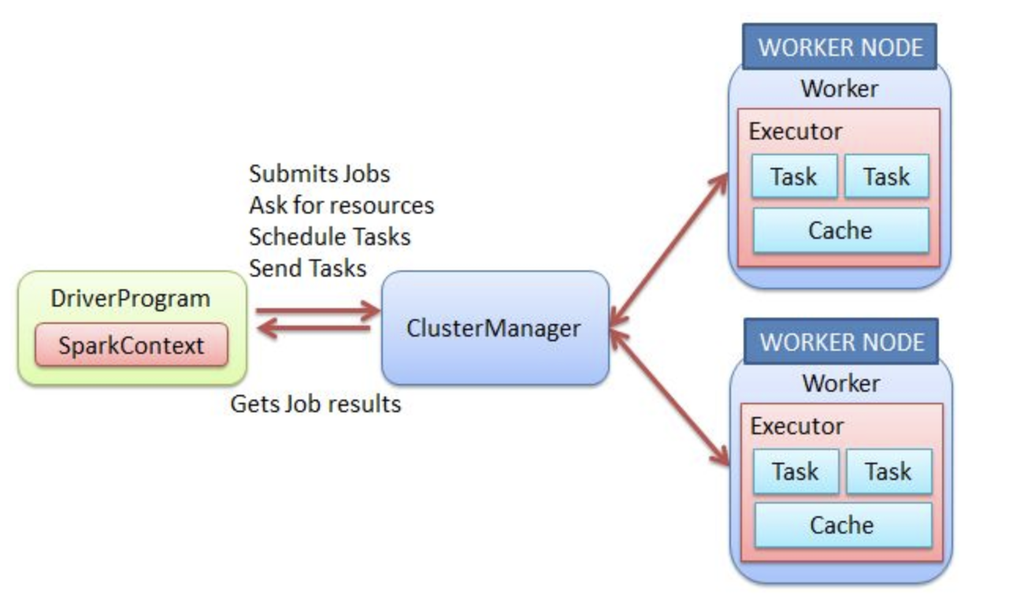

Image taken from: https://annefou.github.io.pyspark/03-pyspark_context/ by Anne Fouilloux

## 1.7 Partitioning

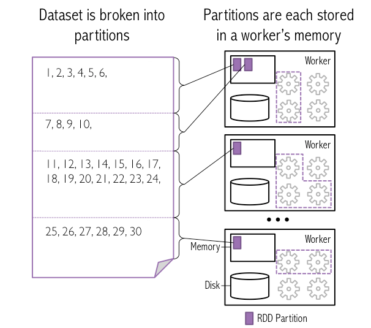

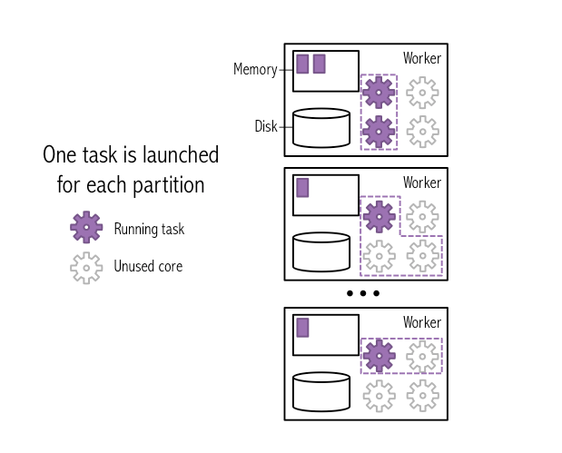

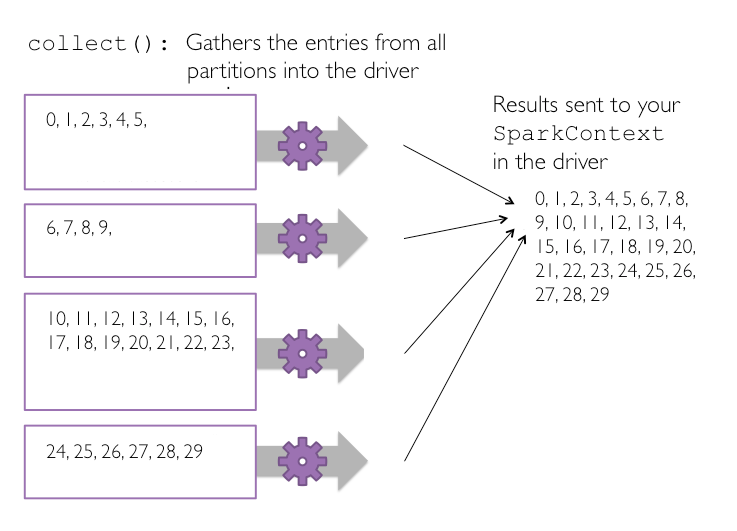

**Note:**

Proper Partitioning: In the diagram there are some cores that are not used because each worker has more cores than partitions and thus, we are wasting resources. We need to think about proper partitioning to optimize those resources.

### 1.7.1 Efficient Partitioning

The importance of partitioning cannot be understated. Suppose that you have access to 8 cores. When thinking about partitioning, the primary aim should be to have our data equally distributed between the cores.

If we have 8 cores, and 1 million records, it stands to reason that we want 125,000 records on each core. Unbalanced partitioning can lead to massive slow done. We want the number of partitions to be a multiple of the number of cores, to ensure that every core is being used equally.

In the first diagram below, if we assume that each partition takes 10 seconds for a task to happen, the total time will be 20 seconds - 10 seconds for the first 8 partitions, and 10 seconds for the last 2. During the last 2, 6 cores are sitting idle.

In the second diagram, with half as many partitions, each twice as large as before. The processing will take 20 seconds, but 3 cores will sit idle for the entire time.

In the diagram below, with the data equally split into 8 partitions, each partition will take 12.5 seconds to process. As each core has only 1 partition, the overall processing time will be 12.5 seconds, with no idle cores.

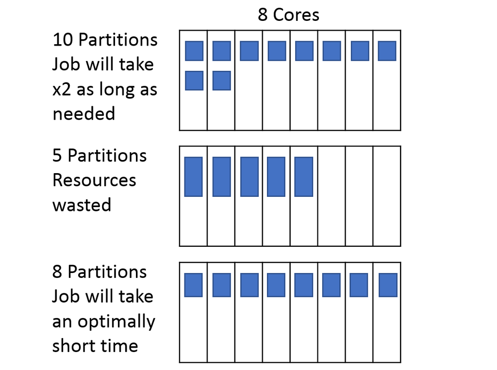

## 1.8 How do I use Spark?

Spark can be run locally, using just the resources of your laptop/computer, or on a cluster. To run Spark on a local machine you need to install Java. If you want to use the Python API, you will need a Python interpreter and if you want to use R, then you need R on your machine. This can be done without any distributed storage system, and is useful for prototyping, development, and debugging.

To harness the full potential of a fully operational cluster, there are two main providers of cloud based Spark facilities, Databricks, and Cloudera. Databricks has a web-based interface, that is available for free in the Databricks Community Edition https://databricks.com/try-databricks, which we will be using.

Within the ONS, the Data Access Platform runs an internally hosted Cloudera Data Science Workbench (CDSW) environment, which allows user definable numbers of clusters, memory allocation, and access to the secure data stored within HUE. HUE, or Hadoop User Experience, is a web interface which gives access to SQL databases, tables, and other data files hosted internally within the ONS. Within CDSW, users can write Python, R, or Scala code to interact with clusters.

## 1.9 Starting with pySpark

The first thing a Spark program must do is to create a SparkSession object, which tells Spark how to access a cluster. A simple SparkSession is created below, but can be tailored Chapter 8).

Within DataBricks, a SparkSession is automatically created with the name spark, ready for use, however within the ONS Data Service , you will need to create your own.

from pyspark.sql import SparkSession

spark = SparkSession.builder.getOrCreate()

You can find pySpark Documentation at https://spark.apache.org/docs/latest/api/python/index.html

# 2 DataFrames

## 2.1 What are they

A DataFrame is a collection of data, organised into named columns - with variables in columns and observations in rows. They are similar to dataframes in R and Python (from the Pandas package), and are built on a foundation of RDDs - as such they share many characteristics, such as immutability. Fundamentally, DataFrames are an expansion of RDDs - they are more efficient, have a large amount of convenient built-in functions, and handle data in a much more structured manner, which is far easier for users to understand intuitively.

DataFrames contain rows of data, with a well defined schema which illustrates the structure of the data - it’s column names and data types.

More information can be found at the links below:

- [databricks - A Tale of Three Apache Spark APIs: RDDs vs DataFrames and Datasets](https://databricks.com/blog/2016/07/14/a-tale-of-three-apache-spark-apis-rdds-dataframes-and-datasets.html)
- [Data Flair - Apache Spark RDD vs DataFrame vs DataSet](https://data-flair.training/blogs/apache-spark-rdd-vs-dataframe-vs-dataset/)

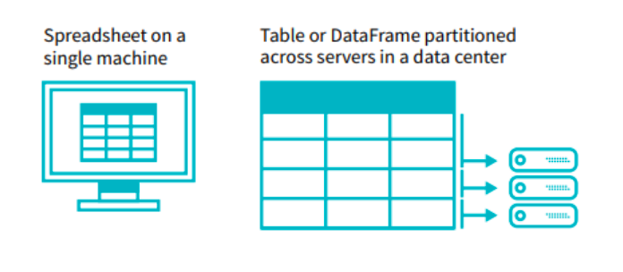

**Note:**

1. Structured Data - information which can be stored in an SQL database in a table with rows and columns and are co-related.
2. Semi-Structured Data - information that is not in a relational database but it is organised in a way that make it easier to analyze eg csv, json, xml files.
3. Unstructured Data - everything else such as videos, photos, audio files.

## 2.2 Why use them

DataFrames can handle structured data, overcoming one of RDDs key limitations.

DataFrames also have APIs available in Python, R, Java, and Scala, and are generally more accessible than RDDs for those new to spark. They however, don’t offer the low-level functionality and control of RDDs.

DataFrames also support different data formats (csv, parquet, Cassandra) and storage systems (Hive tables, mysql etc.).

### 2.2.1 Actions and Transformations

As with the rest of spark, there are two types of operations which can be performed on a DataFrame, transformations, and actions. Any method which takes a DataFrame, manipulates it in some way and returns a new version, is a transformation, while any method which returns something from within the DataFrame (e.g. a count of records, a print of the first few rows) is an action. Due to Spark’s lazy evaluation, transformations are queued up until an action is called.

As such, running a code with just transformations will appear to happen instantly, while then running a **.show()** method to look at the results will take longer - the actual processing occurs at the action call.

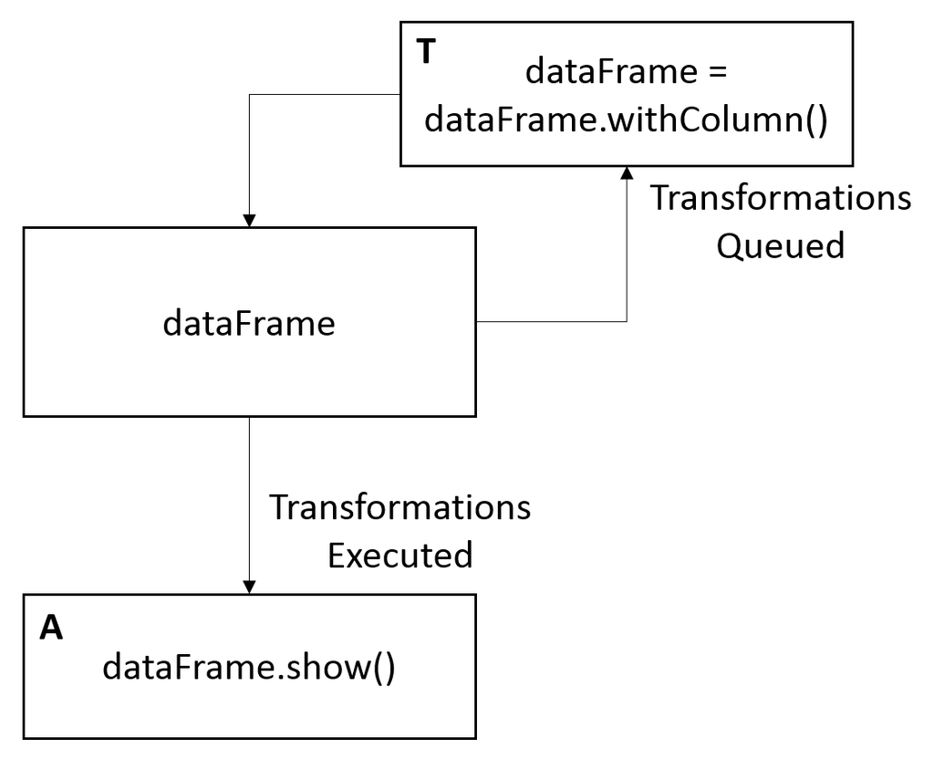

From the Python API, DataFrames have much greater performance than RDDs, due to the inclusion of a built in optimiser. As DataFrames have transformations and actions, transformations will be added to sparks in-built optimiser until an action is called. At this point, the optimiser will determine the most efficient way of completing the required transformations.

## 2.3 Advantages, Drawbacks and Limitations

**Advantages**

1. There is no difference in performance between Scala and Python.
2. Massive performance benefits compared with RDDs.
3. Much more accessible than RDDs - far simpler to operate and use efficiently.

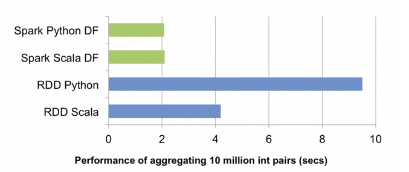

**Drawbacks and Limitations:**

1. Once we have transformed an RDD into a DataFrame we cannot recover the original RDD.
2. Sometimes have to resort to accessing the underlying RDD for increased capability.

A comprehensive comparison of RDDs and DataFrames can be found here:

- [Data Flair - Apache Spark RDD vs DataFrame vs DataSet](https://data-flair.training/blogs/apache-spark-rdd-vs-dataframe-vs-dataset/)

## 2.4 Create them manually

A SparkSession is needed to create DataFrames, export DataFrames as tables, and execute SQL over tables. Within Databricks, one is created automatically with the name **spark**. Within the ONS Data Service, you’ll need to create one manually.

In the last Chapter we will learn how to modify the arguments for the SparkSession.

To create a DataFrame from raw data, define a list of column names, and a list of data, and pass them both to spark.createDataFrame(data, columns). As we can see below, the data should be provided on a row-by-row basis, rather than on a column-by-column basis.

```python
columns = ['id', 'height(cm)', 'weight(kg)']
values = [('A', 160, 60), ('B', 180, 70), ('D', 150, 80)]

DataFrame_from_Scratch = spark.createDataFrame(values, columns)

DataFrame_from_Scratch.show()
```

[output not shown]

[output not shown]

```python
problem_dataframe = spark.createDataFrame(data, columns).show()
```

## 2.5 Import data from external sources

### 2.5.1 From a CSV

**spark.read.csv(path, header)** will read in a CSV file, assign the data to a DataFrame, and if header is set, set the column names to the first row of the file. There are a huge amount of other variables which can be set, including sep to change the separator from a comma, and inferSchema if spark should attempt to infer datatypes automatically from the data.

```python
Item_Price_DataFrame = spark.read.csv('./data/Item_Price_Data.csv', header=True)
Item_Price_DataFrame.show()
```

```
## +-----------+----+-----+---------------+--------+
## |       Item|Code|Price|Last_Year_Price|Quantity|
## +-----------+----+-----+---------------+--------+
## |Black Chair|  22|  100|             70|      10|
## |White Table|   3|  500|            350|      50|
## | Floor Lamp|  16|   60|             50|       1|
## |White Table|   3|  500|            499|      20|
## |      Couch|  12| 1000|            900|       5|
## |White Table|   3|  500|            499|      20|
## +-----------+----+-----+---------------+--------+
```

Within Databricks, the filepath needed is ‘FileStore/tables/filename.csv’.

Within the ONS Data Service, filepaths should start hdfs://prod1/ and from then have the path from within HUE - the Hadoop User Experience file storage solution - appended. E.G. for the ONS BRES dataset, use hdfs://prod1/dapsen/landing_zone/ons/bres22. Full details can be found at [Spark Documentation - pyspark.sql.DataFrameReader(spark)](http://spark.apache.org/docs/2.1.0/api/python/pyspark.sql.html#pyspark.sql.DataFrameReader.csv)

### 2.5.2 From a json file

spark.read.json(path) will read the json file found at path, and assign it to a DataFrame. As with read.csv, there are many different additional variables that can be passed to the function.

```python
Json_File_Item_Price = spark.read.json("./data/Json_File_Item_Price.json")
Json_File_Item_Price.show()
```

```
## +----+-----------+---------------+-----+
## |Code|       Item|Last_Year_Price|Price|
## +----+-----------+---------------+-----+
## |  22|Black Chair|             70|  100|
## |   3|White Table|            350|  500|
## |  16| Floor Lamp|             50|   60|
## |  12|      Couch|            900| 1000|
## |   3|White Table|            499|  500|
## +----+-----------+---------------+-----+
```

### 2.5.3 From an SQL table

SQL commands can be used to read from tables in databases. The below example will accept any valid SQL expression.

Within the ONS Data Service, most data will be stored in SQL tables, so this will probably be the most common import method you come across. Importantly, SQL tables include metadata such as column datatypes - which aren’t explicitly defined in CSV files.

```python
SQL_Item_Price_example = spark.sql('SELECT * FROM database_name.table_name')
```

**Exercises**

1. Import the table ‘department_budget’ into a dataframe using the sql example above. This contains department names, divisions, and budget data - name it something suitable e.g. ‘department_budget’.
2. Display some of the contents of the dataframe, to understand the structure of the data.

**Answers**

```python
department_budget = spark.sql('SELECT * FROM default.department_budget')
department_budget.show()
```

```
## +--------------------+-----------+------+
## |          department|   division|budget|
## +--------------------+-----------+------+
## |                  HR|      Admin|  7852|
## |             Finance|      Admin|  8541|
## |               Legal|      Admin|  9656|
## |       International|      Admin|  1913|
## |         IT Services|  Technical|  7420|
## |         Procurement|      Admin|   744|
## |                 R&D| Scientific|  8389|
## |Software Engineering|Engineering|  6109|
## | Systems Engineering|Engineering|  6564|
## |              Legacy|  Technical|  2581|
## |               Space| Scientific|  7505|
## |             Transit|Engineering|  7069|
## |            Autonomy|Engineering|  4060|
## |                 Air|Engineering|  8712|
## |            Maritime|Engineering|  8480|
## |    Customer Support|      Admin|  8293|
## |            Training|  Technical|  5241|
## |              Brexit|      Admin|  8886|
## |            Planning|      Admin|  5484|
## |           Executive|      Admin|  6967|
## +--------------------+-----------+------+
## only showing top 20 rows
```

To read in the file from a csv, you could do the following instead:

```python
department_budget = spark.read.csv('./data/department_budget.csv', header = True, inferSchema = True)
```

where **inferSchema = True** lets Pyspark work out the data types of the columns, and **header = True** takes the first row and uses it as column names.

**Guidance**

- Within databricks, your database name will be **default** and the table name will be whatever you called it when you imported it - which will by default be **department_budget_csv**. By going to the data tab on the left hand side of databricks, you can see your table names, and by mousing over the desired table the entire name should appear.
- If your results look different, such as the columns being called **_c0**,** _c1**, you might have incorrectly uploaded the data. Delete the previous table of data by going to the data tab, finding the desired table, pressing the down-arrow to the right of the name and selecting Delete. Then, follow the onboarding instructions to reupload the data, making sure to tick the required check boxes on the left hand side!

# 3 Investigate data

## 3.1 Observe raw data

.show(x) will display in a visual format the first x elements of the DataFrame - up to 20 if x is not set.

```python
Item_Price_DataFrame.show(6)
```

```
## +-----------+----+-----+---------------+--------+
## |       Item|Code|Price|Last_Year_Price|Quantity|
## +-----------+----+-----+---------------+--------+
## |Black Chair|  22|  100|             70|      10|
## |White Table|   3|  500|            350|      50|
## | Floor Lamp|  16|   60|             50|       1|
## |White Table|   3|  500|            499|      20|
## |      Couch|  12| 1000|            900|       5|
## |White Table|   3|  500|            499|      20|
## +-----------+----+-----+---------------+--------+
```

If a cell in a column has more than 20 characters, the end will be truncated. This can often lose the exponent value of a number with a lot of decimals, but can be avoided by passing a secondary argument into the function - .show(6, False) where the boolean refers to truncating or not.

```python
data = [(1,1234567891234567891234510.9786)]
columns = ['idx', 'high_precision_data']
hpd = spark.createDataFrame(data, columns)
hpd.show()
```

```
## +---+--------------------+
## |idx| high_precision_data|
## +---+--------------------+
## |  1|1.234567891234567...|
## +---+--------------------+
```

```python
hpd.show(1, False)
```

```
## +---+---------------------+
## |idx|high_precision_data  |
## +---+---------------------+
## |1  |1.2345678912345678E24|
## +---+---------------------+
```

**Exercise**

Display the first 4 records of your department_budget DataFrame.

**Answer**

```python
department_budget.show(4)
```

```
## +-------------+--------+------+
## |   department|division|budget|
## +-------------+--------+------+
## |           HR|   Admin|  7852|
## |      Finance|   Admin|  8541|
## |        Legal|   Admin|  9656|
## |International|   Admin|  1913|
## +-------------+--------+------+
## only showing top 4 rows
```

**Guidance**

- Replace department_budget with the name of your budget DataFrame. Make sure to give your DataFrames sensible names to make referring back to them easier!
- The displayed table says only showing top 4 rows - this means that there are more than 4 rows in the DataFrame, but not ohw many there are in total!

## 3.2 Return data for external use

.collect() will return a list of all rows of a DataFrame - avoid if the size of the data is larger than the size of the driver. .take(n) can be used to return only n rows of the DataFrame.

```python
print(Item_Price_DataFrame.collect())
```

[output not shown]

**Exercises**

1. Run .collect() on your department - employees DataFrame. Try and to understand the results.
2. In a new cell, run .take(n) on your department - employees DataFrame, and replace n to only return the first record.

**Answer**

```python
print(department_employees.collect())
```

```
## [Row(department='Legal', employees=11), Row(department='Applied Science', employees=49), Row(department='Head Office', employees=5), Row(department='Methodology', employees=27)]
```

```python
print(department_employees.take(1))
```

```
## [Row(department='Legal', employees=11)]
```

**Guidance**

- The results are made up of Row objects, where each one is equal to a row of the DataFrame.
- .take() just returns the very first row.
- Remember, don’t use .collect() if you have a very large DataFrame! It will try to pull all of the data into the driver of your system, which could easily cause the driver to crash!

## 3.3 Observe data structure

.printSchema() can be used to print the schema for a DataFrame in a visual tree. A DataFrame’s schema consists of column names, datatypes, and any other key rules for columns.

```python
Item_Price_DataFrame.printSchema()
```

```
## root
##  |-- Item: string (nullable = true)
##  |-- Code: string (nullable = true)
##  |-- Price: string (nullable = true)
##  |-- Last_Year_Price: string (nullable = true)
##  |-- Quantity: string (nullable = true)
```

.dtypes can also be used, to print out a list of tuples of Column name, datatype.

```python
print(Item_Price_DataFrame.dtypes)
```

```
## [('Item', 'string'), ('Code', 'string'), ('Price', 'string'), ('Last_Year_Price', 'string'), ('Quantity', 'string')]
```

**Exercise**

What are the datatypes of the columns in your department - employees DataFrame?

**Answer**

Datatypes can be found by doing either of the commands above:

```python
department_employees.printSchema()
```

```
## root
##  |-- department: string (nullable = true)
##  |-- employees: long (nullable = true)
```

```python
print(department_employees.dtypes)
```

```
## [('department', 'string'), ('employees', 'bigint')]
```

**Guidance**

If you do both, you might notice that printSchema says that the employees column is a long, while dtypes claims it is a bigint. Fundamentally, these are the same thing! They represent an integer, between -9223372036854775808 and 9223372036854775807!